# When Should You Study at IC3? A Visual Story

## About This Story

IC3, Kate Edgar Information Commons Level 3 is one of the most popular study spaces on campus at the University of Auckland. But not all visits are equal: sometimes it’s nearly empty and silent, other times it’s packed and buzzing with noise.

This visual story explores **when IC3 is most and least available**, how **noise levels relate to crowding**, and how conditions have **changed over the observation period**. The data was collected through a Google Form, logging free seat counts, noise levels, and student activities across multiple visits.

## When Is IC3 Most Available?

The chart below shows the average number of free seats recorded across different times of day. This gives a snapshot of **when you’re most likely to find a seat**.

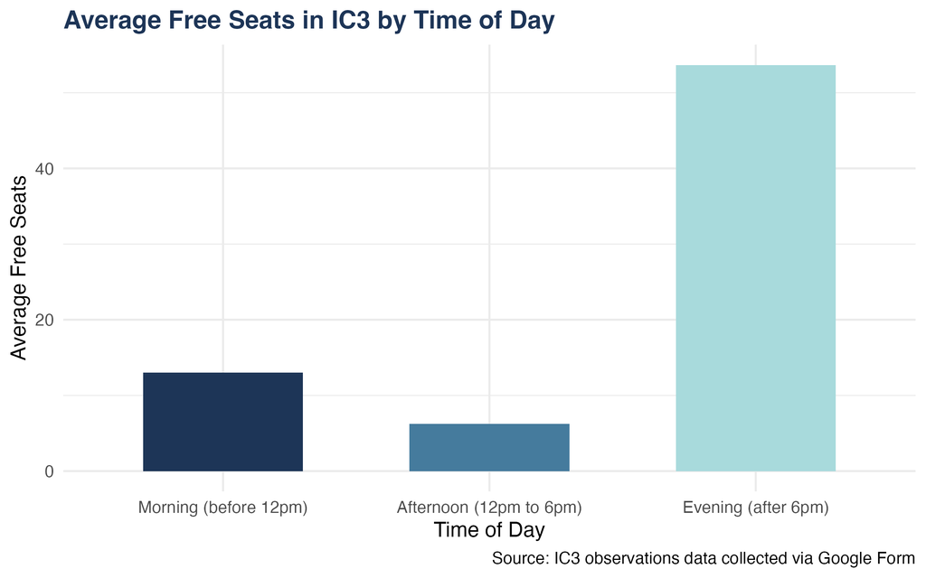

Bar chart showing average free seats in IC3 by time of day. Evening has the highest average seat availability, while afternoon is the most crowded period.

Evening visits recorded the highest average seat availability, while afternoons are by far the busiest. If you’re after a quiet spot with plenty of choice, **heading in after 6pm or before noon** gives you the best chance of finding a seat.

## How Does Availability Vary by Hour?

Each point below represents a single observation, plotted by the hour it was recorded.

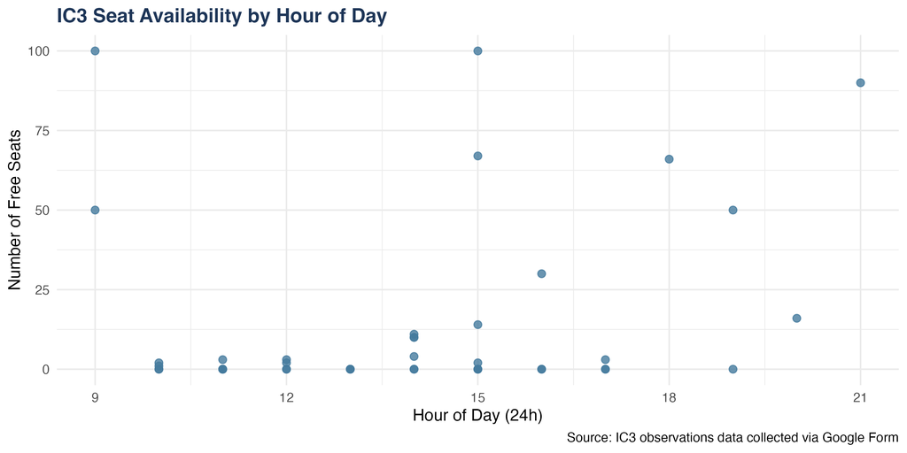

Scatter plot of IC3 seat availability by hour of day.

Seat availability varies across the day, with lower counts tending to cluster in the afternoon hours and higher availability in the morning and evening.

## Does Noise Signal a Crowded Space?

The boxplots below compare the distribution of free seats across different noise levels. If noise and crowding are linked, we would expect quieter sessions to show consistently higher seat availability.

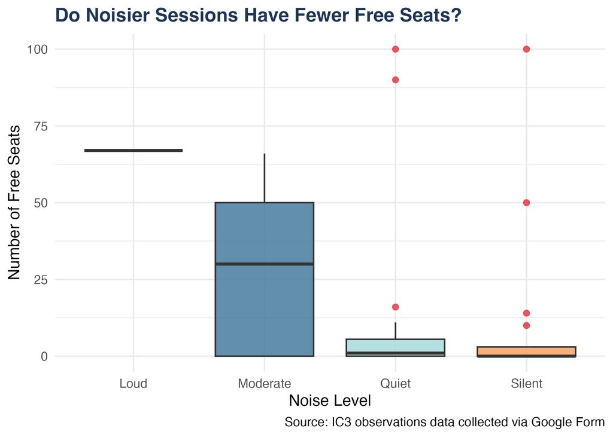